# Health, property and crop damages analyses from the U.S. storm database

Hannon Queiroz

27 July 2017

## Synopsis

This document contains the data acquisation, processing and analyses of the U.S. National Oceanic and Atmospheric Administration’s (NOAA) storm database. It aims to answer the questions mentioned in the Questions section, and it does so by using the knowledge acquired in the first 5 courses of the Data Science Specialization from Coursera. The results are shown in the last section of this document.

## Questions

1. Across the United States, which types of events (as indicated in the EVTYPE variable) are most harmful with respect to population health?
2. Across the United States, which types of events have the greatest economic consequences?

## Getting the data

First, let’s download the data. The data used for this analysis was downloaded on 25/07/2017

```r
fileUrl <- "https://d396qusza40orc.cloudfront.net/repdata%2Fdata%2FStormData.csv.bz2"
if(!file.exists("./dataset.bz2")){
    download.file(fileUrl, destfile="./dataset.bz2", method="curl")
}
```

## Helper functions

#### This section contains some supporting chunks of codes to avoid code repetition.

This function checks if a package is already installed in the system, and installs it if needed

```r
checkAndInstall <- function(pkgName){
    if(pkgName %in% rownames(installed.packages()) == FALSE){
        install.packages(pkgName)
    }
}
```

The next chunk of code will install all the libraries needed for this analysis

```r
checkAndInstall("R.utils")
checkAndInstall("data.table")
checkAndInstall("qdap")
checkAndInstall("dplyr")
checkAndInstall("ggplot2")
```

And this will load all the above libraries.

```r
library(R.utils)
library(qdap)
library(ggplot2)
library(data.table)
library(dplyr)
```

## Loading the data

Because the data is compressed in a `.bz2` file, let’s first uncompress it using the `bunzip2` function from the `R.utils` package.

```r
bunzip2("dataset.bz2", remove = FALSE, skip = TRUE)
```

## Data Processing

Let’s read the data using the `data.table` package. For the purpose of this assignment, only some of the columns in the dataset have been selected.

```r
data <- fread("dataset", sep = ',', na.strings = c(""),
              select = c("EVTYPE", "FATALITIES", "INJURIES",
                         "PROPDMG", "PROPDMGEXP", "CROPDMG",
                         "CROPDMGEXP"))
```

Now, let’s take a look at what our dataset looks like:

```r
print(str(data))
```

```
## Classes 'data.table' and 'data.frame':   902297 obs. of  7 variables:
##  $ EVTYPE    : chr  "TORNADO" "TORNADO" "TORNADO" "TORNADO" ...
##  $ FATALITIES: num  0 0 0 0 0 0 0 0 1 0 ...
##  $ INJURIES  : num  15 0 2 2 2 6 1 0 14 0 ...
##  $ PROPDMG   : num  25 2.5 25 2.5 2.5 2.5 2.5 2.5 25 25 ...
##  $ PROPDMGEXP: chr  "K" "K" "K" "K" ...
##  $ CROPDMG   : num  0 0 0 0 0 0 0 0 0 0 ...
##  $ CROPDMGEXP: chr  NA NA NA NA ...
##  - attr(*, ".internal.selfref")=<externalptr>
## NULL
```

```r
print(head(data))
```

```
##     EVTYPE FATALITIES INJURIES PROPDMG PROPDMGEXP CROPDMG CROPDMGEXP
## 1: TORNADO          0       15    25.0          K       0         NA
## 2: TORNADO          0        0     2.5          K       0         NA
## 3: TORNADO          0        2    25.0          K       0         NA
## 4: TORNADO          0        2     2.5          K       0         NA
## 5: TORNADO          0        2     2.5          K       0         NA
## 6: TORNADO          0        6     2.5          K       0         NA
```

To address the first question, let’s look at the `EVTYPE` column

```r
length(unique(data$EVTYPE))
```

```
## [1] 985
```

We can see that there are way too many entries. Looking at the data may enlighten us as to why that is. The data is sorted before the `print` function is called to make it easier to spot typos.

```r
print(head(sort(unique(data$EVTYPE)), 10))
```

```
##  [1] "   HIGH SURF ADVISORY" " COASTAL FLOOD"
##  [3] " FLASH FLOOD"          " LIGHTNING"
##  [5] " TSTM WIND"            " TSTM WIND (G45)"
##  [7] " WATERSPOUT"           " WIND"
##  [9] "?"                     "ABNORMAL WARMTH"
```

The first cleaning that will be done is to set all the strings to lower case.

```r
data$EVTYPE <- tolower(data$EVTYPE)
```

Secondly, let’s remove all numeric values from the event types, as they are not relevant for this analisys. e.g. replace “hail 0.75” with “hail”

```r
regmatches(
    data$EVTYPE,
    gregexpr("[[:digit:]]+\\.*[[:digit:]]*", data$EVTYPE)
) <- ""
```

Remove all non-alphanumeric characters and remove unecessary whitespaces:

```r
data$EVTYPE <- Trim(clean(gsub("\\W", " ", data$EVTYPE)))
```

Replace “tstm” with “thunderstorm”

```r
data$EVTYPE <- gsub("tstm","thunderstorm", data$EVTYPE)
```

Suppress the hurricane name

```r
data$EVTYPE <- gsub("hurricane.*","hurricane", data$EVTYPE)
```

Since the official event name for thunderstorm-related events is “thunderstorm wind”, we can clean all the thunderstorm-related names.

```r
data$EVTYPE <- gsub(".*thunderstorm.*","thunderstorm wind", data$EVTYPE)
```

Same for snow events

```r
data$EVTYPE <- gsub(".*snow*","heavy snow", data$EVTYPE)
```

Remove all “summary”

```r
data <- data[!grepl("summary", data$EVTYPE), ]
```

Let’s take another look at our dataset now:

```r
print(length(unique(data$EVTYPE)))
```

```
## [1] 566
```

```r
print(head(sort(unique(data$EVTYPE))))
```

```
## [1] ""                    "abnormal warmth"     "abnormally dry"
## [4] "abnormally wet"      "agricultural freeze" "apache county"
```

We have reduced the amount of unique `EVTYPE`s from 985 to 566. It’s still far from our desired 48 entries, but it’s a good start.

Now let’s see which events are more frequent:

```r
freq <- as.data.frame(table(data$EVTYPE))
freq <- arrange(freq, desc(Freq))
colnames(freq) <- c("EVTYPE", "freq")
print(head(freq, 10))
```

```
##               EVTYPE   freq
## 1  thunderstorm wind 336808
## 2               hail 288761
## 3            tornado  60652
## 4        flash flood  54279
## 5              flood  25327
## 6          high wind  20217
## 7         heavy snow  17308
## 8          lightning  15756
## 9         heavy rain  11742
## 10      winter storm  11433
```

For this analysis, we will only consider events that caused at least 1 fatality or casualty.

```r
data_fat <- data

# creating a new column with the sum of fatalities and injuries
data_fat$total <- data_fat$FATALITIES + data_fat$INJURIES

question1 <- filter(data_fat, total > 0)
question1 <- question1 %>%
    group_by(EVTYPE) %>%
    summarise(
        total = sum(total)
    ) %>%
    arrange(desc(total))
print(head(question1))
```

```
## # A tibble: 6 × 2
##              EVTYPE total
##               <chr> <dbl>
## 1           tornado 96979
## 2 thunderstorm wind 10298
## 3    excessive heat  8428
## 4             flood  7259
## 5         lightning  6047
## 6              heat  3037
```

We can see that **tornadoes** and **thunderstorm winds** are the vilains when it comes to health damages. The full result will be shown in the **Results** section.

Now let’s do the analisys in order to answer **Question 2**.  
The next chunk of code will do the following steps:

1. Convert all the expoents variables to lower case.
2. Iterate through the dataset and multiply the number value by the expoent value.
3. Create a new dataset with the final value for each kind of damage.

```r
data$PROPDMGEXP <- tolower(data$PROPDMGEXP)
data$CROPDMGEXP <- tolower(data$CROPDMGEXP)

damages <- do.call(rbind.data.frame, apply(data, 1, function(row){
    damagep <- 0
    propexp <- row[["PROPDMGEXP"]]
    propdmg <- as.numeric(row[["PROPDMG"]])
    if(is.na(propexp)){
        damagep <- 0
    }else if(propexp == "k"){
        damagep <- propdmg*1000
    }else if(propexp == "h"){
        damagep <- propdmg*100
    }else if(propexp == "m"){
        damagep <- propdmg*10e6
    }else if(propexp == "b"){
        damagep <-propdmg*10e9
    }else if(propexp == "+"){
        damagep <- propdmg*1
    }else{
        damagep <- 0
    }

    damagec <- 0
    cropexp <- row[["CROPDMGEXP"]]
    cropdmg <- as.numeric(row[["CROPDMG"]])
    if(is.na(cropexp)){
        damagec <- 0
    }else if(cropexp == "k"){
        damagec <- cropdmg*1000
    }else if(cropexp == "h"){
        damagec <- cropdmg*100
    }else if(cropexp == "m"){
        damagec <- cropdmg*10e6
    }else if(cropexp == "b"){
        damagec <-cropdmg*10e9
    }else if(cropexp == "+"){
        damagec <- cropdmg*1
    }else{
        damagec <- 0
    }

    return(list(total.propdmg=damagep,
                total.cropdmg=damagec))
}))
```

Now we have a `damages` dataframe containing the absolute value for property damages and crop damages. Let’s create a new column called `total.damages` that will add the values of property damages and crop damages.

```r
damages$total.damages <- damages$total.propdmg + damages$total.cropdmg
rownames(damages) <- NULL
rownames(data) <- NULL
```

And now we can merge this dataframe wth the original `data` dataframe so that we can perform the needed calculations.

```r
data <- as.data.frame(data)
merged.data <- merge(data, damages, by="row.names")
print(head(merged.data))
```

```
##   Row.names  EVTYPE FATALITIES INJURIES PROPDMG PROPDMGEXP CROPDMG
## 1         1 tornado          0       15      25          k       0
## 2        10 tornado          0        0      25          k       0
## 3       100    hail          0        0       0       <NA>       0
## 4      1000 tornado          0        2     250          k       0
## 5     10000    hail          0        0       0       <NA>       0
## 6    100000 tornado          0        0       0          k       0
##   CROPDMGEXP total.propdmg total.cropdmg total.damages
## 1       <NA>         25000             0         25000
## 2       <NA>         25000             0         25000
## 3       <NA>             0             0             0
## 4       <NA>        250000             0        250000
## 5       <NA>             0             0             0
## 6       <NA>             0             0             0
```

Finally, we can calculate which events have the greatest economic consequences by summing up the damage values.

```r
most.damages <- merged.data %>%
    group_by(EVTYPE) %>%
    summarise(
        total.damage = sum(total.damages)
    ) %>%
    arrange(desc(total.damage))
print(head(most.damages))
```

```
## # A tibble: 6 × 2
##        EVTYPE total.damage
##         <chr>        <dbl>
## 1       flood 1.493827e+12
## 2   hurricane 9.025334e+11
## 3     tornado 5.441539e+11
## 4 storm surge 4.330679e+11
## 5        hail 1.763164e+11
## 6 flash flood 1.613677e+11
```

From this table, we can see which events have the biggest impact. This result will be analysed in the **Results** section.

## Results

### 1. Question 1

The following plot shows the top 10 harmful events with respect to population health.

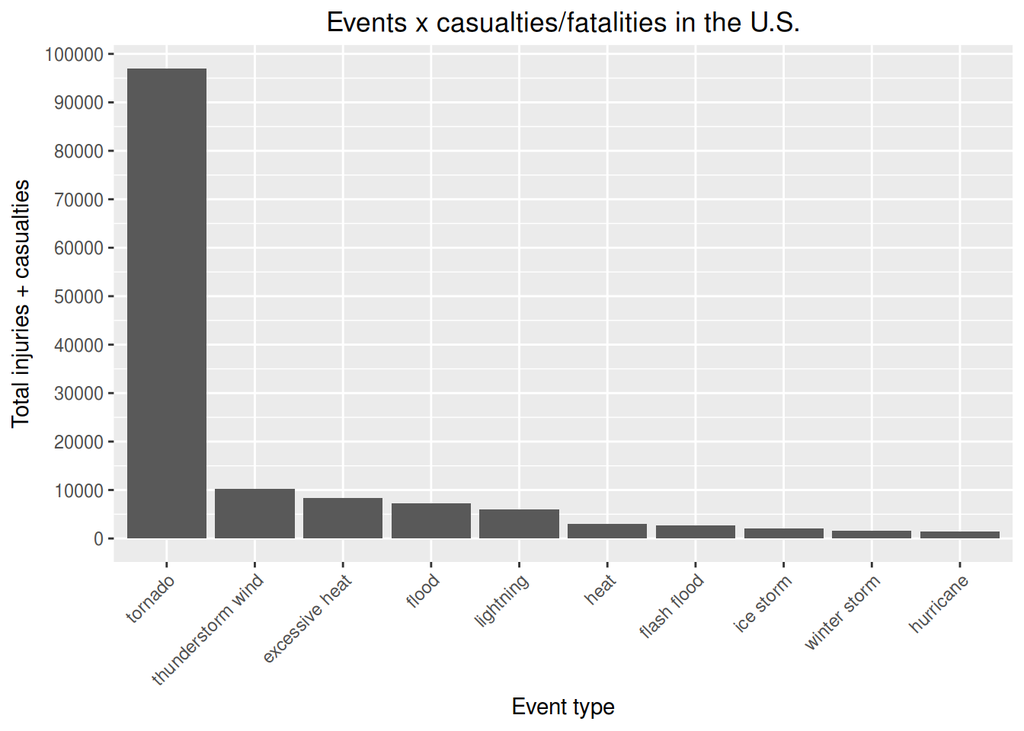

```r
question1 <- as.data.frame(question1[1:10, ])
ggplot(data = question1, aes(x=reorder(EVTYPE, -total), y=total)) +
    geom_bar(stat="identity") +
    theme(axis.text.x = element_text(angle = 45, hjust = 1)) +
    xlab("Event type") +
    ylab("Total injuries + casualties") +
    ggtitle("Events x casualties/fatalities in the U.S.") +
    theme(plot.title = element_text(hjust = 0.5)) +
    scale_y_continuous(breaks=pretty(question1$total, n=10),
                       labels = function(n){format(n, scientific = FALSE)})
```

### 2. Question 2

The next plot shows the 10 events with the greatest economic consequences.

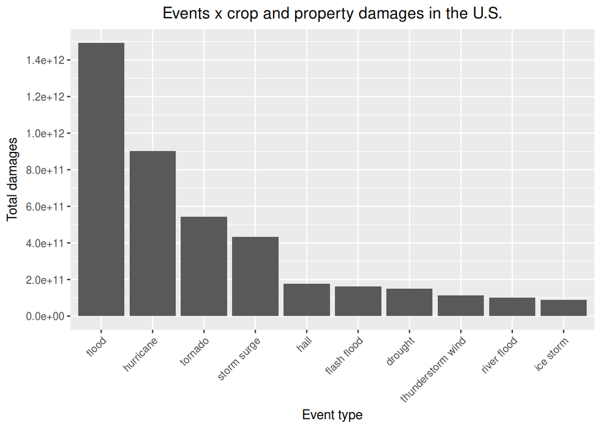

```r
ggplot(data = most.damages[1:10, ], aes(x=reorder(EVTYPE, -total.damage), y=total.damage)) +
    geom_bar(stat="identity") +
    theme(axis.text.x = element_text(angle = 45, hjust = 1)) +
    xlab("Event type") +
    ylab("Total damages") +
    ggtitle("Events x crop and property damages in the U.S.") +
    theme(plot.title = element_text(hjust = 0.5)) +
    scale_y_continuous(breaks=pretty(most.damages$total.damage, n=10))
```

## Acknowledgements

[This post](https://www.coursera.org/learn/reproducible-research/discussions/weeks/4/threads/IdtP_JHzEeaePQ71AQUtYw) by Usama A.F. Khalil was of great help during the developtment of this assignment.

The information to convert the values needed for Question 2 were found [here](https://rstudio-pubs-static.s3.amazonaws.com/58957_37b6723ee52b455990e149edde45e5b6.html).